# Developmental changes in sensitivity to high variance feedback relates to differences in risky decision making

This notebook contains exploratory analyses of behavioral data collected to investigate the relationship between risk taking behavior and probabilistic learning.

The sample consists of three age groups: kids, teens and adults and we hypothesize that sensitivity to learn from high variance feedback improves with age and this is related to better risky decisions.

Subjects completed a probabilistic learning task in the scanner, a realistic risky decision making task (BART) outside the scanner and numerous questionnaires. The focus of this notebook is on the first two tasks.

The plan of analysis is to establish that adults are more sensitive to high variance feedback in the probabilistic learning task and relate this (modeled) sensitivity to behavior in BART.

# Sample info

First let’s get a sense of the sample. Here is how many subjects we have who have complete datasets for the probabilistic learning task and their age break downs.

```r
machine_game_data_clean %>%
  mutate(age_group=factor(age_group, levels=c('kid', 'teen', 'adult'))) %>%
  group_by(age_group) %>%
  summarise(min_age = min(calc_age),
            mean_age = mean(calc_age),
            sd_age = sd(calc_age),
            max_age = max(calc_age),
            n = n()/180)
```

| age_group | min_age | mean_age | sd_age | max_age | n |
| --- | --- | --- | --- | --- | --- |
| kid | 8.81 | 10.97034 | 1.285598 | 12.99 | 29 |
| teen | 13.64 | 15.83353 | 1.229208 | 17.74 | 17 |
| adult | 18.75 | 25.56034 | 4.056775 | 30.80 | 29 |

# Performance in probabilistic learning task

We first examine the behavior in the probabilistic learning task.

In this task subjects are presented with a fractal in each trial. The fractals represent different machines. Subjects choose to play or pass in each trial. Each machine yields a probabilistic reward. There are four machines in total. Two with positive and two with negative expected value. One of each of these machines has a low variance reward schedule while the other has a high variance reward schedule. More clearly:  
- One machine gives $5 90% of the time and -$495 %10 of the time  
- One machine gives -$5 90% of the time and $495 %10 of the time  
- One machine gives $10 50% of the time and -$100 %50 of the time  
- One machine gives -$10 50% of the time and $100 %50 of the time

## Points earned

Performance in this task can be assessed by looking at the total number of points subjects make at the end of task. The following graph shows that adults collect more points in this task compared to kids.

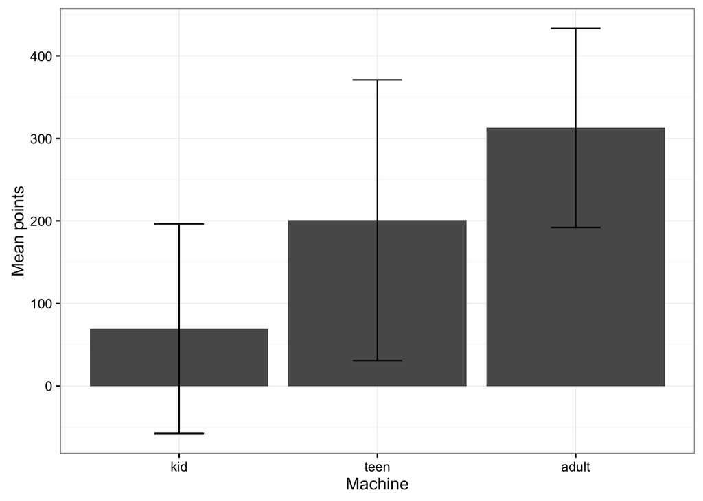

```r
machine_game_data_clean %>%
  group_by(Sub_id, facet_labels) %>%
  summarise(total_points = sum(Points_earned)) %>%
  do(assign.age.info(.)) %>%
  mutate(age_group=factor(age_group, levels=c('kid', 'teen', 'adult'))) %>%
  group_by(age_group) %>%
  summarise(mean_points = mean(total_points),
            sem_points = sem(total_points)) %>%
  ggplot(aes(age_group, mean_points))+
  geom_bar(stat='identity', position = position_dodge((0.9)))+
  geom_errorbar(aes(ymin=mean_points-sem_points, ymax=mean_points+sem_points), position = position_dodge(0.9), width=0.25)+
  theme_bw()+
  xlab('Machine')+
  ylab('Mean points')+
  labs(fill='Age group')
```

This difference is statistically significant: adults earn more points compared to the kids (t = 2.771).

```r
tmp = machine_game_data_clean %>%
  group_by(Sub_id) %>%
  summarise(total_points = sum(Points_earned)) %>%
  do(assign.age.info(.)) %>%
  mutate(age_group=factor(age_group, levels=c('kid', 'teen', 'adult')))

summary(lm(total_points~age_group, data=tmp))
```

```
Call:
lm(formula = total_points ~ age_group, data = tmp)

Residuals:
    Min      1Q  Median      3Q     Max
-2820.0  -957.6  -203.5  1131.9  2416.5

Coefficients:
               Estimate Std. Error t value Pr(>|t|)
(Intercept)       277.6      248.1   1.119   0.2670
age_groupteen     525.9      408.2   1.289   0.2017
age_groupadult    972.4      350.9   2.771   0.0071 **
---
Signif. codes:  0 '***' 0.001 '**' 0.01 '*' 0.05 '.' 0.1 ' ' 1

Residual standard error: 1336 on 72 degrees of freedom
Multiple R-squared:  0.09651,   Adjusted R-squared:  0.07141
F-statistic: 3.845 on 2 and 72 DF,  p-value: 0.0259
```

Since we are interested in the age differences between sensitivity to different feedback schedules, **we should show that this difference in performance exists especially for the high variance feedback condition(s)**. Here is the plot of performance (total points earned) broken down by conditions.

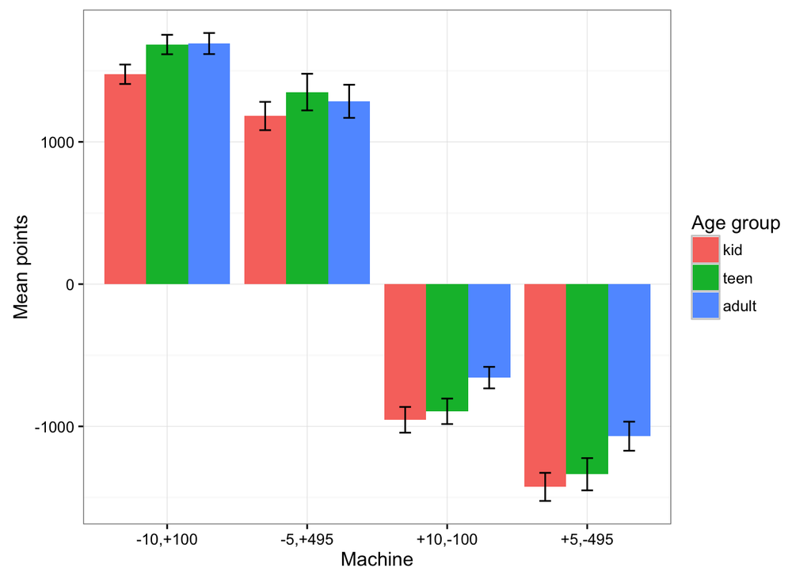

```r
machine_game_data_clean %>%
  group_by(Sub_id, facet_labels) %>%
  summarise(total_points = sum(Points_earned)) %>%
  do(assign.age.info(.)) %>%
  mutate(age_group=factor(age_group, levels=c('kid', 'teen', 'adult'))) %>%
  group_by(age_group, facet_labels) %>%
  summarise(mean_points = mean(total_points),
            sem_points = sem(total_points)) %>%
  ggplot(aes(facet_labels, mean_points, fill=age_group))+
  geom_bar(stat='identity', position = position_dodge((0.9)))+
  geom_errorbar(aes(ymin=mean_points-sem_points, ymax=mean_points+sem_points), position = position_dodge(0.9), width=0.25)+
  theme_bw()+
  xlab('Machine')+
  ylab('Mean points')+
  labs(fill='Age group')
```

The multilevel model below, where the *absolute number of points* in each condition is regressed on age with random intercepts for each subject suggests the following conclusions on performance:

```r
# No sig other than difference between conditions
tmp <- machine_game_data_clean %>%
  group_by(Sub_id, facet_labels) %>%
  summarise(total_points = sum(Points_earned)) %>%
  do(assign.age.info(.)) %>%
  mutate(age_group=factor(age_group, levels=c('kid', 'teen', 'adult')))
summary(lmer(abs(total_points) ~ age_group*facet_labels+(1|Sub_id), data = tmp))
```

```
Linear mixed model fit by REML ['lmerMod']
Formula: abs(total_points) ~ age_group * facet_labels + (1 | Sub_id)
   Data: tmp

REML criterion at convergence: 4405.6

Scaled residuals:
     Min       1Q   Median       3Q      Max
-2.69232 -0.70553  0.00776  0.72576  2.28059

Random effects:
 Groups   Name        Variance Std.Dev.
 Sub_id   (Intercept)  26924   164.1
 Residual             202795   450.3
Number of obs: 300, groups:  Sub_id, 75

Fixed effects:
                                    Estimate Std. Error t value
(Intercept)                          1475.17      89.00  16.575
age_groupteen                         208.95     146.40   1.427
age_groupadult                        215.86     125.87   1.715
facet_labels-5,+495                  -292.93     118.26  -2.477
facet_labels+10,-100                 -521.38     118.26  -4.409
facet_labels+5,-495                   -49.83     118.26  -0.421
age_groupteen:facet_labels-5,+495     -41.19     194.54  -0.212
age_groupadult:facet_labels-5,+495   -110.52     167.25  -0.661
age_groupteen:facet_labels+10,-100   -268.62     194.54  -1.381
age_groupadult:facet_labels+10,-100  -512.41     167.25  -3.064
age_groupteen:facet_labels+5,-495    -297.82     194.54  -1.531
age_groupadult:facet_labels+5,-495   -572.24     167.25  -3.422

Correlation of Fixed Effects:
                  (Intr) ag_grpt ag_grpd f_-5,+ f_+10, f_+5,-
age_grouptn       -0.608
age_gropdlt       -0.707  0.430
fct_-5,+495       -0.664  0.404   0.470
fc_+10,-100       -0.664  0.404   0.470   0.500
fct_+5,-495       -0.664  0.404   0.470   0.500  0.500
ag_grpt:_-5,+495   0.404 -0.664  -0.286  -0.608 -0.304 -0.304
ag_grpd:_-5,+495   0.470 -0.286  -0.664  -0.707 -0.354 -0.354
```

[output cut: 13 more lines]

```
ag_grpd:_+10,-100  0.215            0.500            0.430
ag_grpt:_+5,-495   0.500            0.215            0.500
ag_grpd:_+5,-495   0.215            0.500            0.215
                  ag_grpd:_+10,-100 ag_grpt:_+5,-495
age_grouptn
age_gropdlt
fct_-5,+495
fc_+10,-100
fct_+5,-495
ag_grpt:_-5,+495
ag_grpd:_-5,+495
ag_grpt:_+10,-100
ag_grpd:_+10,-100
ag_grpt:_+5,-495   0.215
ag_grpd:_+5,-495   0.500             0.430
```

The question is what difference in behavior is leading to this difference in performance?

## Proportion of playing

The first thing we can look at is how often do subjects play versus pass. It’s hard to see any age differences when we just look at frequency of overall playing as below.

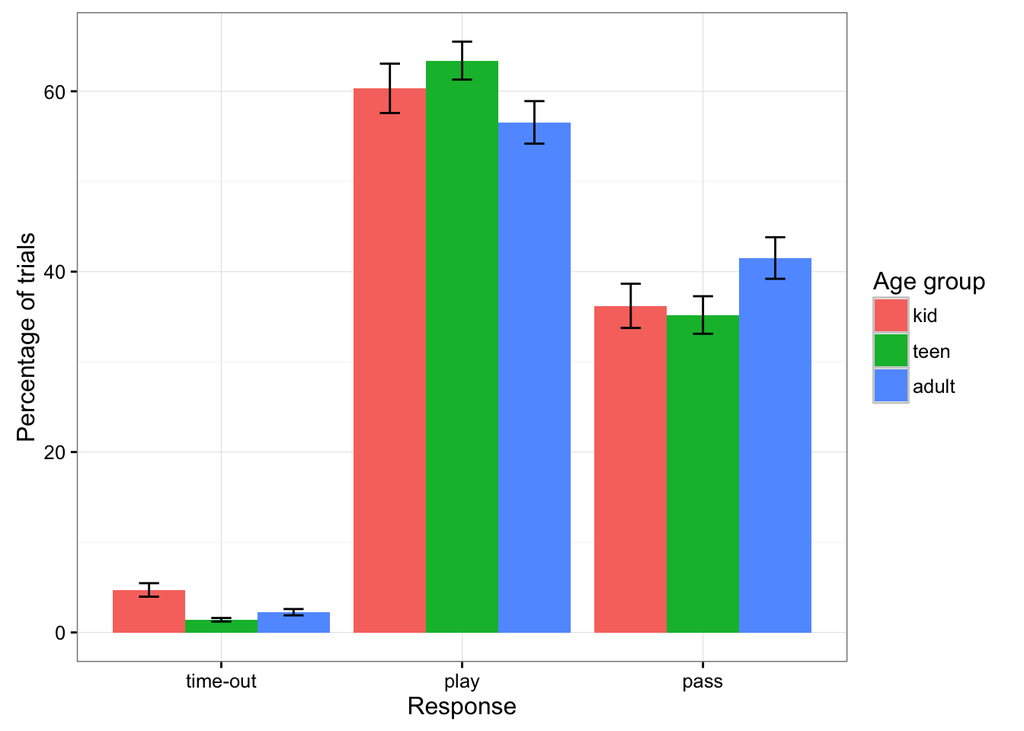

```r
machine_game_data_clean %>%
  mutate(age_group=factor(age_group, levels=c('kid', 'teen', 'adult')),
         Response = factor(Response, levels = c(0,1,2) ,labels=c('time-out', 'play', 'pass'))) %>%
  group_by(Sub_id, Response) %>%
  tally %>%
  group_by(Sub_id) %>%
  mutate(pct=(100*n)/sum(n)) %>%
  do(assign.age.info(.)) %>%
  group_by(age_group, Response) %>%
  dplyr::summarise(mean_pct = mean(pct),
            sem_pct = sem(pct)) %>%
  ggplot(aes(Response, mean_pct, fill = factor(age_group, levels=c('kid', 'teen', 'adult'))))+
  geom_bar(stat='identity', position = position_dodge(0.9))+
  geom_errorbar(aes(ymin = mean_pct - sem_pct, ymax = mean_pct + sem_pct), position = position_dodge(width = 0.9), width=0.25)+
  theme_bw()+
  ylab('Percentage of trials')+
  labs(fill = 'Age group')
```

It is also not immediately apparent how to translate this to better performance/learning in this task but one way to think about it: If people learned perfectly they should play half of the time (always for the positive expected value trial and never for the negative expected value trials). The fact that all play proportions are above 50% suggests that nobody learns perfectly and that adults might be closest to it. But this is very crude and a better way to look at it would be to see  
1. how this depends on the different machines and  
2. how it changes throughout the task.

Just to make sure that this crude measure is not capturing an interesting difference: Do the percentages of played trials differ from each other? No. (Baseline in this regression is how frequently adults timeout so the significant differences only say that they play and pass more than they time out)

```r
tmp = machine_game_data_clean %>%
  mutate(age_group=factor(age_group, levels=c('kid', 'teen', 'adult')),
         Response = factor(Response, levels = c(0,1,2) ,labels=c('time-out', 'play', 'pass'))) %>%
  group_by(Sub_id, Response) %>%
  tally %>%
  group_by(Sub_id) %>%
  mutate(pct=(100*n)/sum(n)) %>%
  do(assign.age.info(.)) %>%
  ungroup()

summary(lm(pct ~ Response*age_group, data = tmp))
```

```
Call:
lm(formula = pct ~ Response * age_group, data = tmp)

Residuals:
    Min      1Q  Median      3Q     Max
-35.996  -3.635  -0.294   3.973  39.119

Coefficients:
                           Estimate Std. Error t value Pr(>|t|)
(Intercept)                  2.2444     2.0586   1.090   0.2768
Responseplay                54.3073     2.8092  19.332   <2e-16 ***
Responsepass                39.2690     2.8092  13.979   <2e-16 ***
age_groupkid                 2.4682     2.8092   0.879   0.3806
age_groupteen               -0.8392     3.2358  -0.259   0.7956
Responseplay:age_groupkid    1.3057     3.8985   0.335   0.7380
Responsepass:age_groupkid   -7.7713     3.9152  -1.985   0.0485 *
Responseplay:age_groupteen   7.6862     4.5118   1.704   0.0899 .
Responsepass:age_groupteen  -5.4781     4.5118  -1.214   0.2260
---
Signif. codes:  0 '***' 0.001 '**' 0.01 '*' 0.05 '.' 0.1 ' ' 1

Residual standard error: 10.29 on 211 degrees of freedom
Multiple R-squared:  0.8424,    Adjusted R-squared:  0.8364
F-statistic:   141 on 8 and 211 DF,  p-value: < 2.2e-16
```

To get a better sense of overall behavior in different contingency states we break this proportion of playing down by machines.

Now we can see age differences in playing frequency in different conditions, particularly in the negative expected value machines (bottom row).

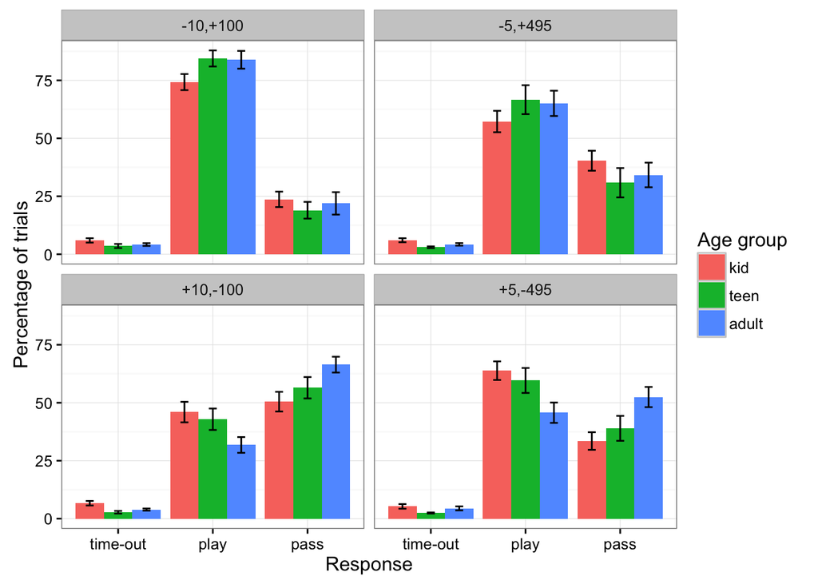

```r
machine_game_data_clean %>%
  mutate(age_group=factor(age_group, levels=c('kid', 'teen', 'adult')),
         Response = factor(Response, levels = c(0,1,2) ,labels=c('time-out', 'play', 'pass'))) %>%
  group_by(Sub_id, facet_labels, Response) %>%
  tally %>%
  group_by(Sub_id, facet_labels) %>%
  mutate(pct=(100*n)/sum(n)) %>%
  do(assign.age.info(.)) %>%
  group_by(age_group, facet_labels, Response) %>%
  dplyr::summarise(mean_pct = mean(pct),
            sem_pct = sem(pct)) %>%
  ggplot(aes(Response, mean_pct, fill = factor(age_group, levels=c('kid', 'teen', 'adult'))))+
  geom_bar(stat='identity', position = position_dodge(0.9))+
  geom_errorbar(aes(ymin = mean_pct - sem_pct, ymax = mean_pct + sem_pct), position = position_dodge(width = 0.9), width=0.25)+
  theme_bw()+
  ylab('Percentage of trials')+
  facet_wrap(~facet_labels)+
  labs(fill = 'Age group')
```

The differences in points earned map directly on to proportion of choosing to play each machine:

- Adults (baseline in the regression below) play most for the low variance positive expected value condition (top left) then significantly less for the high variance positive expected value condition (top right, t = -3.368), even less for high variance negative expected value condition (bottom right, t = -6.842), and least for the low variance negative expected value condition (bottom left, t = -9.333). This pattern reflects a sensitivity to low variance (better learning for low variance conditions comparing the equivalent expected values).
- Teens do not differ significantly from adults in any condition.
- Kids do not differ from adults in playing proportion in the positive expected value conditions (top row; low variance t = -1.633, high variance t = 0.225) but they do choose to play the machine for both of the negative expected value conditions (bottom row; low variance t = 3.015, high variance t = 3.517)

```r
tmp <- machine_game_data_clean %>%
  mutate(age_group=factor(age_group, levels=c('kid', 'teen', 'adult')),
         Response = factor(Response, levels = c(0,1,2) ,labels=c('time-out', 'play', 'pass'))) %>%
  group_by(Sub_id, facet_labels, Response) %>%
  tally %>%
  group_by(Sub_id, facet_labels) %>%
  mutate(pct_play=(100*n)/sum(n)) %>%
  filter(Response == 'play') %>%
  do(assign.age.info(.))

summary(lmer(pct_play ~ age_group*facet_labels + (1|Sub_id), data = tmp))
```

```
Linear mixed model fit by REML ['lmerMod']
Formula: pct_play ~ age_group * facet_labels + (1 | Sub_id)
   Data: tmp

REML criterion at convergence: 2642.6

Scaled residuals:
     Min       1Q   Median       3Q      Max
-2.65914 -0.69208  0.03646  0.75004  1.97139

Random effects:
 Groups   Name        Variance Std.Dev.
 Sub_id   (Intercept)  50.81    7.128
 Residual             451.18   21.241
Number of obs: 300, groups:  Sub_id, 75

Fixed effects:
                                   Estimate Std. Error t value
(Intercept)                         83.8632     4.1605  20.157
age_groupkid                        -9.6103     5.8839  -1.633
age_groupteen                        0.5813     6.8439   0.085
facet_labels-5,+495                -18.7866     5.5782  -3.368
facet_labels+10,-100               -52.0624     5.5782  -9.333
facet_labels+5,-495                -38.1671     5.5782  -6.842
age_groupkid:facet_labels-5,+495     1.7751     7.8887   0.225
age_groupteen:facet_labels-5,+495    1.0088     9.1758   0.110
age_groupkid:facet_labels+10,-100   23.7866     7.8887   3.015
age_groupteen:facet_labels+10,-100  10.4938     9.1758   1.144
age_groupkid:facet_labels+5,-495    27.7457     7.8887   3.517
age_groupteen:facet_labels+5,-495   13.3305     9.1758   1.453

Correlation of Fixed Effects:
                  (Intr) ag_grpk ag_grpt f_-5,+ f_+10, f_+5,-
age_groupkd       -0.707
age_grouptn       -0.608  0.430
fct_-5,+495       -0.670  0.474   0.408
fc_+10,-100       -0.670  0.474   0.408   0.500
fct_+5,-495       -0.670  0.474   0.408   0.500  0.500
ag_grpk:_-5,+495   0.474 -0.670  -0.288  -0.707 -0.354 -0.354
ag_grpt:_-5,+495   0.408 -0.288  -0.670  -0.608 -0.304 -0.304
```

[output cut: 13 more lines]

```
ag_grpt:_+10,-100  0.215            0.500            0.430
ag_grpk:_+5,-495   0.500            0.215            0.500
ag_grpt:_+5,-495   0.215            0.500            0.215
                  ag_grpt:_+10,-100 ag_grpk:_+5,-495
age_groupkd
age_grouptn
fct_-5,+495
fc_+10,-100
fct_+5,-495
ag_grpk:_-5,+495
ag_grpt:_-5,+495
ag_grpk:_+10,-100
ag_grpt:_+10,-100
ag_grpk:_+5,-495   0.215
ag_grpt:_+5,-495   0.500             0.430
```

This is not surprising given what the number of points earned already showed. But now that we are looking at a behavioral measure instead of an outcome measure we might be able to quantify constructs of interest like sensitivity to variance or sensitivity to the expected values of the machines.

Initially I tried defining these in terms of probability of playing a machine but as I worked through this I have changed my mind about the dependent variable these changes should be defined by (or rather the coding of the dependent variable). I kept confusing myself about when playing a machine was ‘good’ or suggested learning. So I recoded the choices to be `correct` when a subject chooses to play a positive expected value machine and pass a negative expected value machine and `incorrect` when the reverse is true. If a subject is learning they should be learning to play the positive expected machines and to pass the others.

## Learning

Recoding the behavior in this way gave a clearer picture of the age difference *in learning* between the conditions.

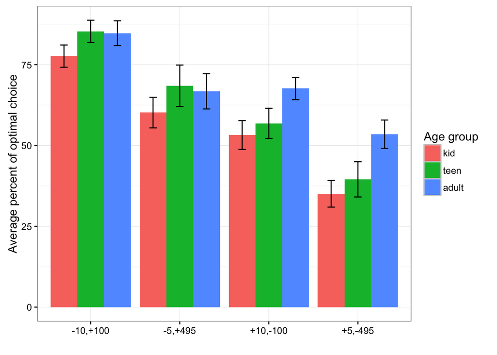

```r
machine_game_data_clean %>%
  filter(Response %in% c(1,2)) %>%
  mutate(correct1_incorrect0 = ifelse(facet_labels %in% c('-10,+100', '-5,+495') & Response ==1,1,ifelse(facet_labels %in% c('+10,-100', '+5,-495') & Response ==2,1,0)),
         age_group=factor(age_group, levels=c('kid', 'teen', 'adult')),
         Response = factor(Response, levels = c(0,1,2) ,labels=c('time-out', 'play', 'pass')))%>%
  group_by(Sub_id, facet_labels, correct1_incorrect0) %>%
  tally %>%
  group_by(Sub_id, facet_labels) %>%
  mutate(pct_correct=(100*n)/sum(n)) %>%
  filter(correct1_incorrect0 == 1) %>%
  do(assign.age.info(.)) %>%
  select(-n, -correct1_incorrect0) %>%
  group_by(facet_labels, age_group) %>%
  summarise(mean_pct_correct = mean(pct_correct, na.rm=T),
            sem_pct_correct = sem(pct_correct)) %>%
  ggplot(aes(facet_labels, mean_pct_correct, fill = factor(age_group, levels=c('kid', 'teen', 'adult'))))+
  geom_bar(stat='identity', position=position_dodge(0.9))+
  geom_errorbar(aes(ymin=mean_pct_correct-sem_pct_correct, ymax=mean_pct_correct+sem_pct_correct), position = position_dodge(0.9), width=0.25)+
  theme_bw()+
  ylab('Average percent of optimal choice')+
  labs(fill = 'Age group')+
  xlab('')
```

**But** it also showed that there is a lot of individual variabilitiy. The multilevel regression below with individual intercepts for each subject regressing the correct choices on age group and condition suggests that close to 40% variance might be due to random effects. It also shows that the fixed effects are not signigicantly different for kids in any condition.

```r
tmp = machine_game_data_clean %>%
  filter(Response %in% c(1,2)) %>%
  mutate(correct1_incorrect0 = ifelse(facet_labels %in% c('-10,+100', '-5,+495') & Response ==1,1,ifelse(facet_labels %in% c('+10,-100', '+5,-495') & Response ==2,1,0)),
         age_group=factor(age_group, levels=c('kid', 'teen', 'adult')),
         Response = factor(Response, levels = c(0,1,2) ,labels=c('time-out', 'play', 'pass')))%>%
  group_by(Sub_id, facet_labels, correct1_incorrect0) %>%
  tally %>%
  group_by(Sub_id, facet_labels) %>%
  mutate(pct_correct=(100*n)/sum(n)) %>%
  filter(correct1_incorrect0 == 1) %>%
  do(assign.age.info(.)) %>%
  select(-n, -correct1_incorrect0)

summary(lmer(pct_correct ~ age_group*facet_labels + (1|Sub_id), data = tmp))
```

```
Linear mixed model fit by REML ['lmerMod']
Formula: pct_correct ~ age_group * facet_labels + (1 | Sub_id)
   Data: tmp

REML criterion at convergence: 2583.5

Scaled residuals:
     Min       1Q   Median       3Q      Max
-2.92415 -0.51133  0.05956  0.62492  2.42142

Random effects:
 Groups   Name        Variance Std.Dev.
 Sub_id   (Intercept) 196.7    14.03
 Residual             313.3    17.70
Number of obs: 298, groups:  Sub_id, 75

Fixed effects:
                                   Estimate Std. Error t value
(Intercept)                         84.7322     4.1937  20.205
age_groupkid                        -7.0881     5.9307  -1.195
age_groupteen                        0.5773     6.8984   0.084
facet_labels-5,+495                -17.9762     4.6481  -3.867
facet_labels+10,-100               -17.1150     4.6481  -3.682
facet_labels+5,-495                -31.2469     4.6481  -6.722
age_groupkid:facet_labels-5,+495     0.5091     6.5734   0.077
age_groupteen:facet_labels-5,+495    1.1266     7.6460   0.147
age_groupkid:facet_labels+10,-100   -6.6583     6.6108  -1.007
age_groupteen:facet_labels+10,-100 -11.3414     7.6460  -1.483
age_groupkid:facet_labels+5,-495   -10.7219     6.6108  -1.622
age_groupteen:facet_labels+5,-495  -14.5385     7.6460  -1.901

Correlation of Fixed Effects:
                  (Intr) ag_grpk ag_grpt f_-5,+ f_+10, f_+5,-
age_groupkd       -0.707
age_grouptn       -0.608  0.430
fct_-5,+495       -0.554  0.392   0.337
fc_+10,-100       -0.554  0.392   0.337   0.500
fct_+5,-495       -0.554  0.392   0.337   0.500  0.500
ag_grpk:_-5,+495   0.392 -0.554  -0.238  -0.707 -0.354 -0.354
ag_grpt:_-5,+495   0.337 -0.238  -0.554  -0.608 -0.304 -0.304
```

[output cut: 13 more lines]

```
ag_grpt:_+10,-100  0.215            0.500            0.427
ag_grpk:_+5,-495   0.497            0.214            0.497
ag_grpt:_+5,-495   0.215            0.500            0.214
                  ag_grpt:_+10,-100 ag_grpk:_+5,-495
age_groupkd
age_grouptn
fct_-5,+495
fc_+10,-100
fct_+5,-495
ag_grpk:_-5,+495
ag_grpt:_-5,+495
ag_grpk:_+10,-100
ag_grpt:_+10,-100
ag_grpk:_+5,-495   0.214
ag_grpt:_+5,-495   0.500             0.427
```

This large between subjects variability suggested that we should look at the behavior at a finer grain instead of just aggregating across age groups. Since we are interested in learning to begin with we look at change in choosing the *optimal* action for a machine across time.

Here is a plot of change in choosing the correct action for each machine depending on the number of times that machine has been encountered (centered as explained below)

Things to note for this plot:  
- There is a lot of individual variability in learning (the thin lines in the background are all over the place)  
- Aggregated for age groups it looks like there is no learning in the positive expected value machines (flat lines in the top row). **This seems confusing**  
- Still learning in the high variance positive expected value condition appears lower on aggregate (top row left right comparison)  
- Kids look like they learn best in the low variance negative expected value machine (slope of red line in bottom left quadrant)  
- The age difference in learning appears only in the high variance negative expected value machine (difference between the three line in the bottom right quadrant)

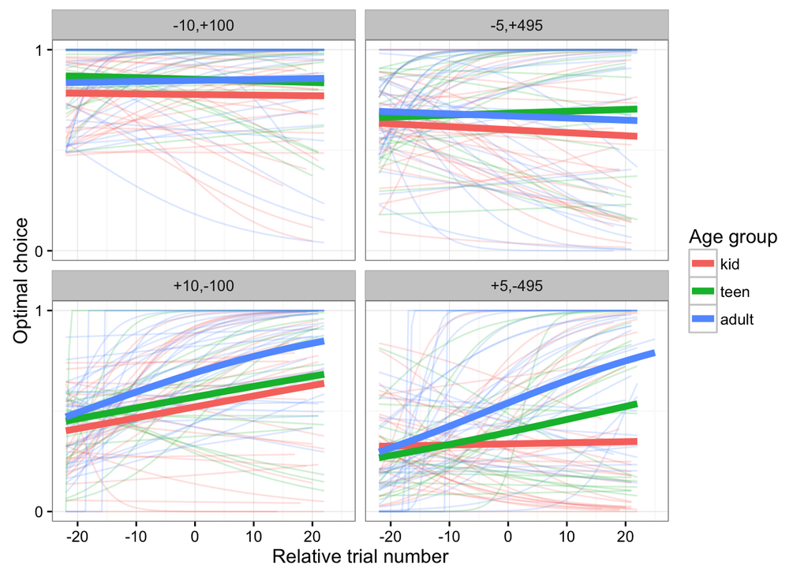

```r
machine_game_data_clean %>%
  filter(Response %in% c(1,2)) %>%
  group_by(Sub_id, facet_labels) %>%
  mutate(trial = (1:n())-23,
         correct1_incorrect0 = ifelse(facet_labels %in% c('-10,+100', '-5,+495') & Response ==1,1,ifelse(facet_labels %in% c('+10,-100', '+5,-495') & Response ==2,1,0))) %>%
  ggplot(aes(trial, correct1_incorrect0))+
  geom_line(aes(group = Sub_id, col= factor(age_group, levels=c('kid', 'teen', 'adult'))),stat='smooth', method = 'glm', method.args = list(family = "binomial"), se = FALSE, alpha=0.2)+
  geom_line(aes(col= factor(age_group, levels=c('kid', 'teen', 'adult'))),stat='smooth', method = 'glm', method.args = list(family = "binomial"), se = FALSE, alpha=1, size=2)+
  facet_wrap(~facet_labels)+
  theme_bw()+
  xlab("Relative trial number")+
  scale_y_continuous(breaks=c(0,1))+
  labs(col="Age group")+
  ylab('Optimal choice')
```

Based on these graphs I checked for age difference in three variables:  
- The intercept: whether they are more or less likely to choose the optimal action having seen half of the trials (since trial number is centered within machine).  
- The slope: which direction and how fast the sigmoid moves in (for learning this must be positive and the larger it is the better the learning)  
- The learning index: where they are at 50% for each machine (switch point - I came up with this to see if there was a systematic change in both parameters that might be interesting. I’m not sure if it makes sense.)

```r
get_learning_coef <- function(data){
  model = glm(correct1_incorrect0 ~ trial, family = binomial(link=logit), data = data)
  b0 = coef(model)[1]
  b1 = coef(model)[2]
  learnIndex = -b0/b1
  return(data.frame(b0, b1, learnIndex))
}


tmp = machine_game_data_clean %>%
  filter(Response %in% c(1,2)) %>%
  group_by(Sub_id, facet_labels) %>%
  mutate(trial = (1:n())-23,
         correct1_incorrect0 = ifelse(facet_labels %in% c('-10,+100', '-5,+495') & Response ==1,1,ifelse(facet_labels %in% c('+10,-100', '+5,-495') & Response ==2,1,0))) %>%
  do(get_learning_coef(.)) %>%
  do(assign.age.info(.))
```

The age difference in slopes across the conditions looks as follows (again reflecting the large variability):

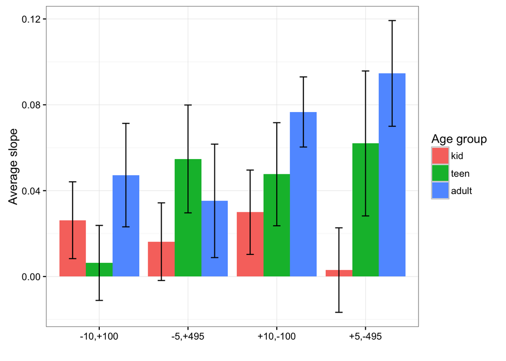

```r
machine_game_data_clean %>%
  filter(Response %in% c(1,2)) %>%
  group_by(Sub_id, facet_labels) %>%
  mutate(trial = (1:n())-23,
         correct1_incorrect0 = ifelse(facet_labels %in% c('-10,+100', '-5,+495') & Response ==1,1,ifelse(facet_labels %in% c('+10,-100', '+5,-495') & Response ==2,1,0))) %>%
  do(get_learning_coef(.)) %>%
  do(assign.age.info(.)) %>%
  select(-b0, -learnIndex) %>%
  filter(b1<1) %>%
  group_by(age_group, facet_labels) %>%
  summarise(mean_b1 = mean(b1),
            sem_b1 = sem(b1)) %>%
  ggplot(aes(facet_labels, mean_b1, fill = factor(age_group, levels=c('kid', 'teen', 'adult'))))+
  geom_bar(stat='identity', position=position_dodge(0.9))+
  geom_errorbar(aes(ymin=mean_b1-sem_b1, ymax=mean_b1+sem_b1), position = position_dodge(0.9), width=0.25)+
  theme_bw()+
  ylab('Average slope')+
  labs(fill = 'Age group')+
  xlab('')
```

```r
summary(lmer(b1 ~ age_group*facet_labels + (1|Sub_id), data = tmp))
```

```
Linear mixed model fit by REML ['lmerMod']
Formula: b1 ~ age_group * facet_labels + (1 | Sub_id)
   Data: tmp

REML criterion at convergence: 1758

Scaled residuals:
    Min      1Q  Median      3Q     Max
-2.0365 -0.3608  0.0005  0.0641  6.5669

Random effects:
 Groups   Name        Variance Std.Dev.
 Sub_id   (Intercept)  5.406   2.325
 Residual             18.975   4.356
Number of obs: 300, groups:  Sub_id, 75

Fixed effects:
                                    Estimate Std. Error t value
(Intercept)                         0.047245   0.916901   0.052
age_groupkid                       -0.021024   1.296694  -0.016
age_groupteen                      -0.040917   1.508263  -0.027
facet_labels-5,+495                -0.011998   1.143949  -0.010
facet_labels+10,-100                2.496379   1.143949   2.182
facet_labels+5,-495                 3.811671   1.143949   3.332
age_groupkid:facet_labels-5,+495    0.002005   1.617789   0.001
age_groupteen:facet_labels-5,+495   0.060452   1.881747   0.032
age_groupkid:facet_labels+10,-100  -2.492658   1.617789  -1.541
age_groupteen:facet_labels+10,-100 -0.389683   1.881747  -0.207
age_groupkid:facet_labels+5,-495   -3.834898   1.617789  -2.370
age_groupteen:facet_labels+5,-495  -3.756007   1.881747  -1.996

Correlation of Fixed Effects:
                  (Intr) ag_grpk ag_grpt f_-5,+ f_+10, f_+5,-
age_groupkd       -0.707
age_grouptn       -0.608  0.430
fct_-5,+495       -0.624  0.441   0.379
fc_+10,-100       -0.624  0.441   0.379   0.500
fct_+5,-495       -0.624  0.441   0.379   0.500  0.500
ag_grpk:_-5,+495   0.441 -0.624  -0.268  -0.707 -0.354 -0.354
ag_grpt:_-5,+495   0.379 -0.268  -0.624  -0.608 -0.304 -0.304
```

[output cut: 13 more lines]

```
ag_grpt:_+10,-100  0.215            0.500            0.430
ag_grpk:_+5,-495   0.500            0.215            0.500
ag_grpt:_+5,-495   0.215            0.500            0.215
                  ag_grpt:_+10,-100 ag_grpk:_+5,-495
age_groupkd
age_grouptn
fct_-5,+495
fc_+10,-100
fct_+5,-495
ag_grpk:_-5,+495
ag_grpt:_-5,+495
ag_grpk:_+10,-100
ag_grpt:_+10,-100
ag_grpk:_+5,-495   0.215
ag_grpt:_+5,-495   0.500             0.430
```

For reference here are the distributions and regressions on the intercepts and the learn indices as well.

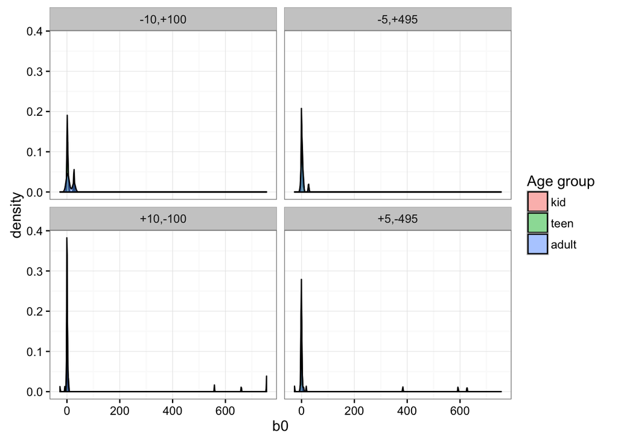

```r
machine_game_data_clean %>%
  filter(Response %in% c(1,2)) %>%
  group_by(Sub_id, facet_labels) %>%
  mutate(trial = (1:n())-23,
         correct1_incorrect0 = ifelse(facet_labels %in% c('-10,+100', '-5,+495') & Response ==1,1,ifelse(facet_labels %in% c('+10,-100', '+5,-495') & Response ==2,1,0))) %>%
  do(get_learning_coef(.)) %>%
  do(assign.age.info(.)) %>%
  select(-b1, -learnIndex) %>%
  ggplot(aes(b0, fill = factor(age_group, levels=c('kid', 'teen', 'adult'))))+
  geom_density(position = 'identity', alpha = 0.5)+
  theme_bw()+
  facet_wrap(~facet_labels)+
  labs(fill = 'Age group')
```

```r
summary(lmer(b0 ~ age_group*facet_labels + (1|Sub_id), data = tmp))
```

```
Linear mixed model fit by REML ['lmerMod']
Formula: b0 ~ age_group * facet_labels + (1 | Sub_id)
   Data: tmp

REML criterion at convergence: 3392.5

Scaled residuals:
    Min      1Q  Median      3Q     Max
-1.9357 -0.3651  0.0059  0.0812  8.2408

Random effects:
 Groups   Name        Variance Std.Dev.
 Sub_id   (Intercept) 1530     39.11
 Residual             5559     74.56
Number of obs: 300, groups:  Sub_id, 75

Fixed effects:
                                   Estimate Std. Error t value
(Intercept)                         10.1683    15.6352   0.650
age_groupkid                        -5.7435    22.1115  -0.260
age_groupteen                       -2.3242    25.7192  -0.090
facet_labels-5,+495                 -6.9117    19.5809  -0.353
facet_labels+10,-100                33.0485    19.5809   1.688
facet_labels+5,-495                 45.9299    19.5809   2.346
age_groupkid:facet_labels-5,+495     5.0159    27.6915   0.181
age_groupteen:facet_labels-5,+495    0.8385    32.2097   0.026
age_groupkid:facet_labels+10,-100  -38.2323    27.6915  -1.381
age_groupteen:facet_labels+10,-100   4.0333    32.2097   0.125
age_groupkid:facet_labels+5,-495   -51.9699    27.6915  -1.877
age_groupteen:facet_labels+5,-495  -54.2136    32.2097  -1.683

Correlation of Fixed Effects:
                  (Intr) ag_grpk ag_grpt f_-5,+ f_+10, f_+5,-
age_groupkd       -0.707
age_grouptn       -0.608  0.430
fct_-5,+495       -0.626  0.443   0.381
fc_+10,-100       -0.626  0.443   0.381   0.500
fct_+5,-495       -0.626  0.443   0.381   0.500  0.500
ag_grpk:_-5,+495   0.443 -0.626  -0.269  -0.707 -0.354 -0.354
ag_grpt:_-5,+495   0.381 -0.269  -0.626  -0.608 -0.304 -0.304
```

[output cut: 13 more lines]

```
ag_grpt:_+10,-100  0.215            0.500            0.430
ag_grpk:_+5,-495   0.500            0.215            0.500
ag_grpt:_+5,-495   0.215            0.500            0.215
                  ag_grpt:_+10,-100 ag_grpk:_+5,-495
age_groupkd
age_grouptn
fct_-5,+495
fc_+10,-100
fct_+5,-495
ag_grpk:_-5,+495
ag_grpt:_-5,+495
ag_grpk:_+10,-100
ag_grpt:_+10,-100
ag_grpk:_+5,-495   0.215
ag_grpt:_+5,-495   0.500             0.430
```

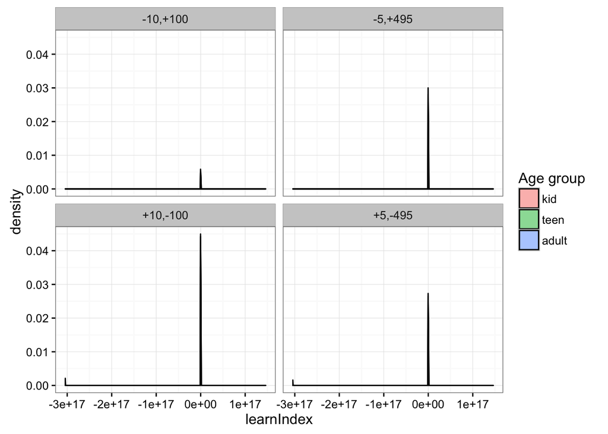

```r
machine_game_data_clean %>%
  filter(Response %in% c(1,2)) %>%
  group_by(Sub_id, facet_labels) %>%
  mutate(trial = (1:n())-23,
         correct1_incorrect0 = ifelse(facet_labels %in% c('-10,+100', '-5,+495') & Response ==1,1,ifelse(facet_labels %in% c('+10,-100', '+5,-495') & Response ==2,1,0))) %>%
  do(get_learning_coef(.)) %>%
  do(assign.age.info(.)) %>%
  select(-b1, -b0) %>%
  ggplot(aes(learnIndex, fill = factor(age_group, levels=c('kid', 'teen', 'adult'))))+
  geom_density(position = 'identity', alpha = 0.5)+
  theme_bw()+
  facet_wrap(~facet_labels)+
  labs(fill = 'Age group')
```

```r
summary(lmer(learnIndex ~ age_group*facet_labels + (1|Sub_id), data = tmp))
```

```
Linear mixed model fit by REML ['lmerMod']
Formula: learnIndex ~ age_group * facet_labels + (1 | Sub_id)
   Data: tmp

REML criterion at convergence: 22602.7

Scaled residuals:
    Min      1Q  Median      3Q     Max
-9.1353 -0.1502  0.0000  0.0750  5.1795

Random effects:
 Groups   Name        Variance  Std.Dev.
 Sub_id   (Intercept) 2.070e+32 1.439e+16
 Residual             4.851e+32 2.203e+16
Number of obs: 300, groups:  Sub_id, 75

Fixed effects:
                                     Estimate Std. Error t value
(Intercept)                         3.401e+10  4.885e+15   0.000
age_groupkid                       -1.896e+10  6.909e+15   0.000
age_groupteen                       1.048e+16  8.036e+15   1.304
facet_labels-5,+495                -2.955e+10  5.784e+15   0.000
facet_labels+10,-100               -3.401e+10  5.784e+15   0.000
facet_labels+5,-495                -3.401e+10  5.784e+15   0.000
age_groupkid:facet_labels-5,+495   -1.343e+10  8.180e+15   0.000
age_groupteen:facet_labels-5,+495  -1.048e+16  9.515e+15  -1.101
age_groupkid:facet_labels+10,-100  -1.050e+16  8.180e+15  -1.283
age_groupteen:facet_labels+10,-100 -1.048e+16  9.515e+15  -1.101
age_groupkid:facet_labels+5,-495   -1.050e+16  8.180e+15  -1.283
age_groupteen:facet_labels+5,-495  -1.048e+16  9.515e+15  -1.101

Correlation of Fixed Effects:
                  (Intr) ag_grpk ag_grpt f_-5,+ f_+10, f_+5,-
age_groupkd       -0.707
age_grouptn       -0.608  0.430
fct_-5,+495       -0.592  0.419   0.360
fc_+10,-100       -0.592  0.419   0.360   0.500
fct_+5,-495       -0.592  0.419   0.360   0.500  0.500
ag_grpk:_-5,+495   0.419 -0.592  -0.254  -0.707 -0.354 -0.354
ag_grpt:_-5,+495   0.360 -0.254  -0.592  -0.608 -0.304 -0.304
```

[output cut: 13 more lines]

```
ag_grpt:_+10,-100  0.215            0.500            0.430
ag_grpk:_+5,-495   0.500            0.215            0.500
ag_grpt:_+5,-495   0.215            0.500            0.215
                  ag_grpt:_+10,-100 ag_grpk:_+5,-495
age_groupkd
age_grouptn
fct_-5,+495
fc_+10,-100
fct_+5,-495
ag_grpk:_-5,+495
ag_grpt:_-5,+495
ag_grpk:_+10,-100
ag_grpt:_+10,-100
ag_grpk:_+5,-495   0.215
ag_grpt:_+5,-495   0.500             0.430
```

## Does this correlate with BART?

Quick look at how this relates to BART data:

```r
adjusted.pumps <- function(subject_data){
  subject_data_adjusted = subject_data[subject_data$exploded == 0,]
  subject_pumps <- subject_data_adjusted %>%
    group_by(trial.num) %>%
    summarise(total_pumps = sum(finished))
  out <- data.frame(mean_adjusted_pumps = mean(subject_pumps$total_pumps))
  return(out)
}
```

Increase in number of pumps with age

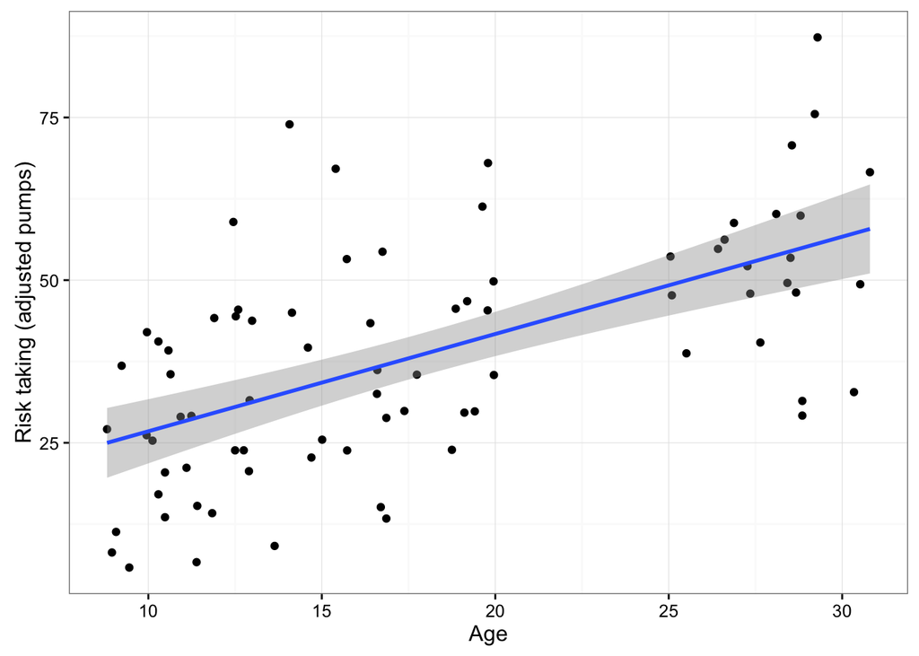

```r
bart_data %>%
  group_by(Sub_id) %>%
  do(adjusted.pumps(.)) %>%
  do(assign.age.info(.)) %>%
  ggplot(aes(x=calc_age, y = mean_adjusted_pumps))+
  geom_point()+
  theme_bw()+
  geom_smooth(method = "lm") +
  xlab("Age")+
  ylab("Risk taking (adjusted pumps)")
```

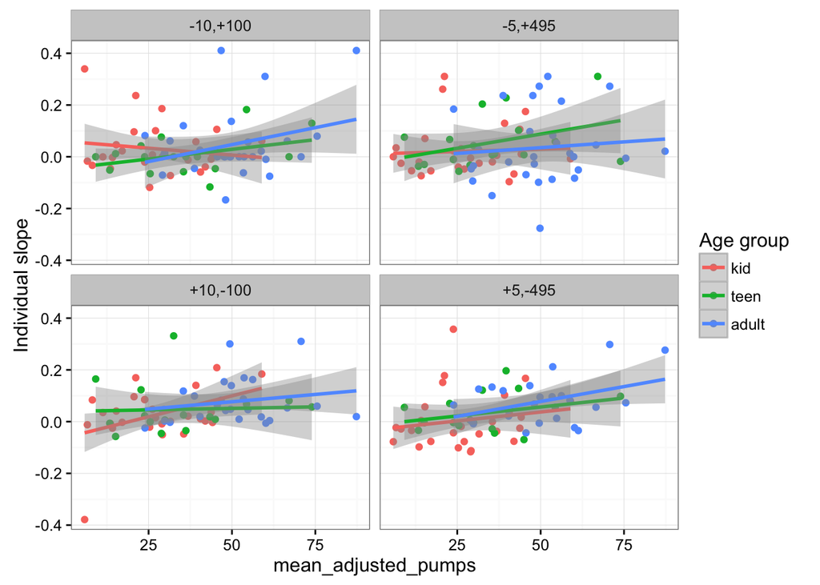

```r
tmp = bart_data %>%
  group_by(Sub_id) %>%
  do(adjusted.pumps(.)) %>%
  do(assign.age.info(.)) %>%
  select(Sub_id, mean_adjusted_pumps)

machine_game_data_clean %>%
  filter(Response %in% c(1,2)) %>%
  group_by(Sub_id, facet_labels) %>%
  mutate(trial = (1:n())-23,
         correct1_incorrect0 = ifelse(facet_labels %in% c('-10,+100', '-5,+495') & Response ==1,1,ifelse(facet_labels %in% c('+10,-100', '+5,-495') & Response ==2,1,0))) %>%
  do(get_learning_coef(.)) %>%
  do(assign.age.info(.)) %>%
  left_join(tmp, by = 'Sub_id') %>%
  filter(b1 < 0.5, b1> (-0.5)) %>%
  ggplot(aes(mean_adjusted_pumps, b1, col = factor(age_group, levels=c('kid', 'teen', 'adult'))))+
  geom_point()+
  geom_smooth(method = 'lm')+
  facet_wrap(~facet_labels)+
  theme_bw()+
  labs(col="Age group")+
  ylab('Individual slope')
```

```r
machine_game_data_clean %>%
  filter(Response %in% c(1,2)) %>%
  group_by(Sub_id, facet_labels) %>%
  mutate(trial = (1:n())-23,
         correct1_incorrect0 = ifelse(facet_labels %in% c('-10,+100', '-5,+495') & Response ==1,1,ifelse(facet_labels %in% c('+10,-100', '+5,-495') & Response ==2,1,0))) %>%
  do(get_learning_coef(.)) %>%
  do(assign.age.info(.)) %>%
  left_join(tmp, by = 'Sub_id') %>%
  group_by(facet_labels, age_group) %>%
  summarise(cor = cor.test(b1, mean_adjusted_pumps)$estimate,
            p_value = cor.test(b1, mean_adjusted_pumps)$p.value)
```

| facet_labels | age_group | cor | p_value |
| --- | --- | --- | --- |
| -10,+100 | adult | 0.29598822 | 0.11899652 |
| -10,+100 | kid | -0.14779648 | 0.46192027 |
| -10,+100 | teen | 0.36958272 | 0.14427749 |
| -5,+495 | adult | 0.09173780 | 0.63600443 |
| -5,+495 | kid | 0.05119315 | 0.79981512 |
| -5,+495 | teen | 0.37595761 | 0.13695104 |
| +10,-100 | adult | 0.07394750 | 0.70303591 |
| +10,-100 | kid | 0.41382583 | 0.03188854 |
| +10,-100 | teen | 0.06664503 | 0.79939040 |
| +5,-495 | adult | 0.05803560 | 0.76491262 |

[output cut: 2 more lines]

## Sensitivity to variance vs. expected value

How should we define these?

Sensitivity to variance is defined as the difference in proportion of playing machines of same expected value.  
Sensitivity to expected value is defined as the difference in proportion of playing machines of same variance.